# **Predicting White Wine Alcohol Content and Quality from Physicochemical Properties**

## Regression

**Linear regression**

```r
# can density predict alcohol content
s_lm<- lm(alcohol ~ density, data = binary_wine)
summary(s_lm)
```

```
##
## Call:
## lm(formula = alcohol ~ density, data = binary_wine)
##
## Residuals:
##     Min      1Q  Median      3Q     Max
## -2.6218 -0.5393  0.0143  0.5315  2.5757
##
## Coefficients:
##             Estimate Std. Error t value Pr(>|t|)
## (Intercept)   348.03      12.38   28.12   <2e-16 ***
## density      -339.56      12.45  -27.27   <2e-16 ***
## ---
## Signif. codes:  0 '***' 0.001 '**' 0.01 '*' 0.05 '.' 0.1 ' ' 1
##
## Residual standard error: 0.7811 on 498 degrees of freedom
## Multiple R-squared:  0.5988, Adjusted R-squared:  0.598
## F-statistic: 743.4 on 1 and 498 DF,  p-value: < 2.2e-16
```

From the above, density accounts for approximately 60% of the variation in alcohol content and with p-value< 0.05 this relationship is significant.

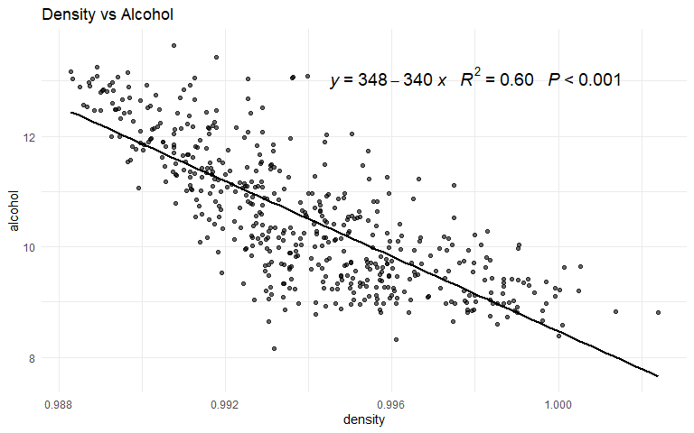

Figure 8: Simple linear regression model

The best multiple linear regression model describing the relationship between alcohol and the other variables including quality is alcohol = 296.67 + 0.135 * fixed.acidity + 1.439 * volatile.acidity + 0.661 * citric.acid - 11.454 * chlorides - 293.605 * density + 0.897 * pH + 0.309 * quality. From the adjusted $R^2$, the model accounts for approximately 72% of the variation in alcohol content and with p-value < 0.05, this relationship is significant. VIF scores were all below 5, indicating the absence of multicollinearity.

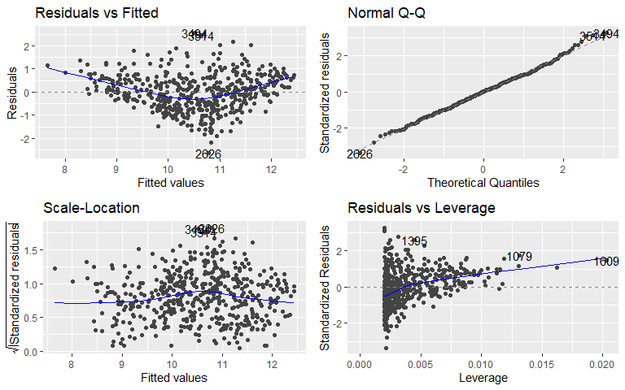

Figure 9: Simple linear regression model diagnostic plot

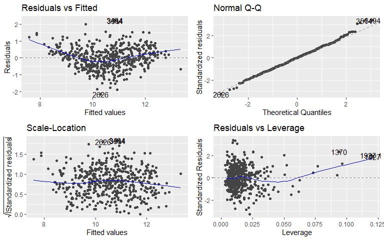

Figure 10: Multiple linear regression model diagnostic plot

The diagnostic plots of the linear models showed deviation from linearity due to line curvature in the residuals vs fitted plot, some heteroscedasticity in the scale-location plot, and slight deviations from normality in the Q-Q plot. Generally, most points on the residuals vs leverage plot have low leverage. There is a possibility that these issues stem from the non-normal distribution of alcohol content.

Comparing all three linear models, the reduced linear model has the lowest AIC and BIC values, making it the best model based on parsimony and model fit. With its p-value < 0.05 and lower than the other models, the relationships defined by this model are statistically significant.

Table 3: Comparing linear regression models

| Model | Model_Details | Adj_r_sqr | AIC | BIC | P_value | F_statistic |
| --- | --- | --- | --- | --- | --- | --- |
| best_multiple_regression_model | alcohol ~ fixed.acidity + volatile.acidity + citric.acid + chlorides + density + pH + quality | 0.7117604 | 1015.554 | 1053.486 | 4.923294e-130 | 177.0284 |
| full_multiple_regression_model | alcohol ~ fixed.acidity + volatile.acidity + citric.acid + chlorides + free.sulfur.dioxide + density + pH + sulphates + quality | 0.7108544 | 1019.087 | 1065.447 | 6.951422e-128 | 137.3083 |
| simple_linear_model | alcohol ~ density | 0.5980372 | 1175.898 | 1188.542 | 7.748342e-101 | 743.4086 |

**Logistic regression**

Table 4: Comparing logistic regression models

| Model | AIC | BIC |
| --- | --- | --- |
| Reduced | 526.3926 | 543.2510 |
| Full | 536.2065 | 578.3526 |

Based on the chosen logistic model, chlorides are not a statistically significant predictor as their p-value is greater than 0.05. Keeping all other parameters constant, a unit increase in volatile acidity will decrease the odds of a white wine being considered good (quality ≥6) by between 89% and 100%. Given the same conditions, a unit increase in alcohol will increase the odds of the wine being good quality by between 118% and 245%.

Table 5: Best logistic model statistcs in percentage format

| term | estimate | pct_change | pct_lower | pct_upper | p.value |
| --- | --- | --- | --- | --- | --- |
| alcohol | 2.7200504 | 172.01 | 117.90 | 2.452700e+02 | 0.0000000 |
| volatile.acidity | 0.0099006 | -99.01 | -99.92 | -8.895000e+01 | 0.0002363 |
| chlorides | 2295.8431893 | 229484.32 | -85.99 | 1.024738e+10 | 0.1326537 |

## Predictions and Cross Validation

**Multiple Linear Regression** From 10-fold cross-validation, the best multiple linear regression model was again the reduced model as shown in Table 6.

Table 6: Comparison of 10-fold cross validation on multiple linear regression models

| Model | RMSE | Rsquared | MAE |
| --- | --- | --- | --- |
| Full | 0.6749516 | 0.7132408 | 0.5299289 |
| Reduced | 0.6678173 | 0.7117096 | 0.5276692 |

**Logistic Regression**

From the confusion matrix, the model correctly classified 286 wines as good (True Positives), which contributes to its high sensitivity of 0.854, indicating that the model is very good at classifying good wines. Only 83 wines were correctly classified as poor, explaining the low specificity of 0.503, indicating that the model is not very good at classifying poor wines, possibly due to the sample distribution imbalance. 82 poor wines were incorrectly classified as good (False Positives) and 49 good wines were incorrectly classified as bad (False Negatives). Although the model achieves high accuracy of 73.8%, the low specificity of 0.503 and the imbalance in the sample may mean that the model works well at classifying good wines but not as well at classifying poor wines. The Kappa value of 0.376 means that the model is performing 37.6% better at predicting wine quality compared to random guessing.

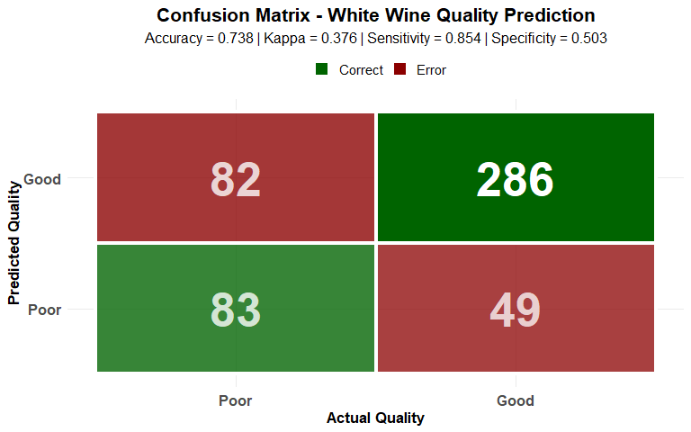

Figure 10: Confusion matrix

# Conclusion

This study examined two research questions: whether physicochemical properties can predict alcohol content in white wines, and whether these properties can classify wine quality. Using smoothed bootstrapping to simulate 500 observations from the UCI Machine Learning Repository dataset, multiple linear regression and binary logistic regression were employed with 10-fold cross-validation. The analysis demonstrated that physicochemical properties effectively predict both outcomes. For alcohol content prediction, the multiple linear regression model explained 71% of variability (adjusted $R^2$ = 0.71, RMSE = 0.67), with density emerging as the strongest predictor ($\beta$ = -293.61, p < 0.001). This negative relationship indicates that lower density wines contain higher alcohol content, consistent with alcohol’s lower specific gravity compared to water. Additional significant predictors included volatile acidity, fixed acidity, and pH. For quality classification, the logistic regression model achieved 73.8% accuracy. Alcohol content demonstrated the strongest association with quality (r = 0.46, p < 0.001), with each unit increase raising odds of good quality by 118-245%. Conversely, volatile acidity significantly decreased quality odds by 89-100%, reflecting its association with vinegar-like off-flavors. These findings validate the use of objective laboratory measurements for wine quality assessment, providing a reproducible alternative to subjective sensory evaluation.

However, several limitations warrant consideration:

- The modest Kappa statistic (0.376) suggests only fair agreement between predicted and actual classifications, indicating room for improvement.
- The simulated sample size (n = 500) was substantially smaller than the original dataset (n = 4,898), potentially limiting statistical power.
- Diagnostic plots revealed slight curvature in residuals and minor deviations from normality, suggesting that linear assumptions may not be perfectly satisfied.
- Finally, this analysis focused exclusively on white wines, limiting applicability to red wines or other varieties.

Therefore, future research should address these limitations through the following approaches:

- Larger sample sizes would increase statistical power and potentially improve Kappa values.
- Including red wines would enable comparison of quality predictors across wine types.
- Exploring polynomial terms or interaction effects might better capture non-linear relationships observed in diagnostic plots.
- External validation on independent datasets would confirm general model acceptance.
- Finally, incorporating additional predictors such as grape variety, vineyard location, or production methods could enhance predictive accuracy.

The practical implications are significant for the wine industry. Producers can use these models for quality control during production, adjusting chemical properties to achieve desired quality targets. The approach provides objective, reproducible quality assessment that complements traditional sensory evaluation. Ultimately, this study demonstrates that statistical techniques combined with physicochemical analysis offer valuable tools for wine quality prediction and optimization.

# Methods

The methods employed in the project can be summarized with the flowchart in Figure 11.

[interactive chart not shown]

Figure 11: Project flowchart

The white wine dataset was downloaded from the UCI Machine Learning Repository (UCI Machine Learning Repository 2009). A quick EDA of the dataset revealed there were 4,898 rows and 12 columns of data, with quality appearing to be the response variable which was ordinal. Most of the data appeared positively skewed, which informed the decision in the simulation method.

**Simulation - Smoothed Bootstrapping**

To maintain the relationships between the variables, smoothed bootstrapping was employed where 500 datapoints were randomly sampled with replacement across all columns except quality, then noise equivalent to 10% of the standard deviation was added to introduce variability from the original dataset. This ensured that the relationships and correlations were maintained. Quality was kept as it was in the original dataset.

**Validation, EDA and Preprocessing**

To check that the simulated and original datasets were similar, a comparison was run which confirmed this through their means, standard deviations and correlation coefficients. As binomial logistic regression was planned, a binary variable was created from quality where good wines = quality ≥6 and poor wines = quality <6. Descriptive statistics including barplots, boxplots and histograms were performed on both groups. The correlation matrix of the predictors against quality showed some collinearity between predictors, leading to feature engineering where residual sugar and total sulfur dioxide were removed from the dataset going forward.

**Initial Hypotheses Testing**

Correlation tests were conducted to determine if there was any significant relationship between quality and alcohol. Normality tests using combined Q-Q plot, boxplot and histogram alongside Shapiro-Wilk test were conducted to check the normality of the alcohol distribution. A t-test was conducted to check if there was a significant difference in the means of alcohol content in the good and poor groups of white wine.

**Linear Regression**

Logistic regression with family binomial was used to create a model to predict good and bad wines (quality_binary) from the predictors in the dataset. As with linear regression, a full model was fitted, then using backward elimination and the step function, the best model was also fitted. R-squared, adjusted R-squared, p-values, VIF, AIC and BIC were used to assess how much of the variability of the response variables was predicted by the predictors, significance, multicollinearity, model fit and parsimony. Predictions and Cross Validation Data values were created to use the models to predict the response variables. 10-fold cross-validation was used to validate the models by splitting the data into training and testing sets. Cross-validation data was then used to create a confusion matrix, Kappa value, accuracy score, sensitivity and specificity values.

# References

Agyemang, Perpetual. 2015. “Wine Quality Prediction Using Data Mining Techniques.” Master's thesis, Youngstown State University. https://digital.maag.ysu.edu/xmlui/bitstream/handle/1989/10638/Agyemang%20Perpetual%20APPROVED.pdf?sequence=3&isAllowed=y.

Cartaya, Claudia. 2020. “Comparison of the Logistic Regression, Decision Tree, and Random Forest Models to Predict Red Wine...” *Towards Data Science*. https://towardsdatascience.com/comparison-of-the-logistic-regression-decision-tree-and-random-forest-models-to-predict-red-wine-313d012d6953/.

Cortez, Paulo, António Cerdeira, Fernando Almeida, Telmo Matos, and José Reis. 2009. “Modeling Wine Preferences by Data Mining from Physicochemical Properties.” *Decision Support Systems* 47 (4): 547–53. https://doi.org/10.1016/j.dss.2009.05.016.

MBA, Terence Shin, MSc. 2020. “Predicting Wine Quality with Several Classification Techniques.” *Towards Data Science*. https://towardsdatascience.com/predicting-wine-quality-with-several-classification-techniques-179038ea6434/.

“Red Wine Quality Classification with Logistic Regression by Gupse Eyşan Toy Medium.” n.d. Accessed December 10, 2025. https://medium.com/@toyg_68342/red-wine-quality-classification-with-logistic-regression-8cbe6aa12b67.

UCI Machine Learning Repository. 2009. “Wine Quality Data Set.” https://archive.ics.uci.edu/dataset/186/wine+quality.

# Appendix

## Original Data

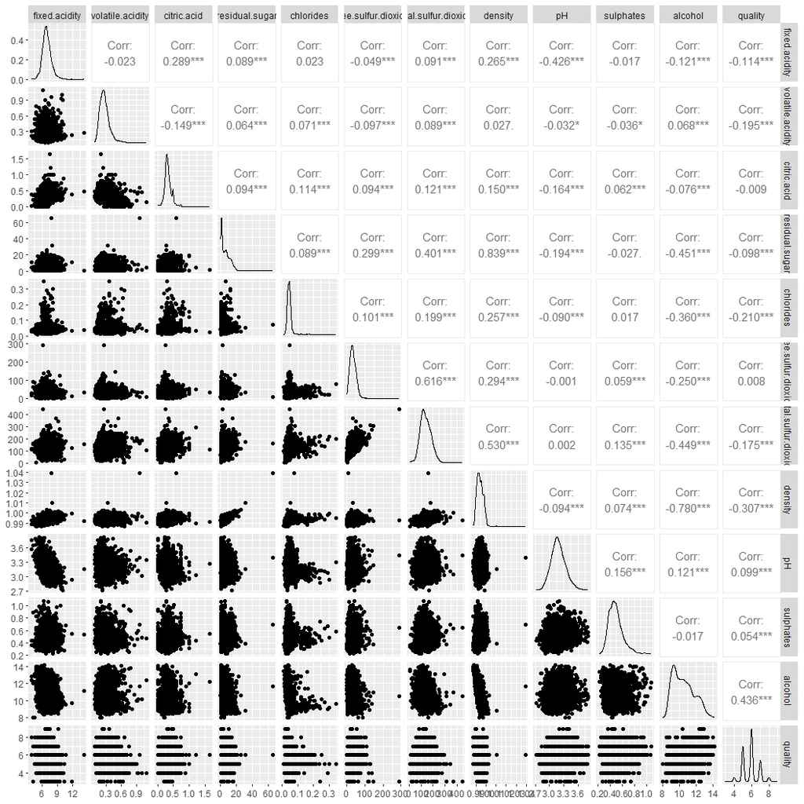

Fig A1 : Original Data GGpairs

Data Frame Summary

wine

**Dimensions**: 4898 x 12  
**Duplicates**: 937

| **No** | **Variable** | **Stats / Values** | **Freqs (% of Valid)** | **Graph** | **Valid** | **Missing** |
| --- | --- | --- | --- | --- | --- | --- |
| 1 | fixed.acidity [numeric] | Mean (sd) : 6.9 (0.8) min ≤ med ≤ max: 3.8 ≤ 6.8 ≤ 14.2 IQR (CV) : 1 (0.1) | 68 distinct values |  | 4898 (100.0%) | 0 (0.0%) |
| 2 | volatile.acidity [numeric] | Mean (sd) : 0.3 (0.1) min ≤ med ≤ max: 0.1 ≤ 0.3 ≤ 1.1 IQR (CV) : 0.1 (0.4) | 125 distinct values |  | 4898 (100.0%) | 0 (0.0%) |
| 3 | citric.acid [numeric] | Mean (sd) : 0.3 (0.1) min ≤ med ≤ max: 0 ≤ 0.3 ≤ 1.7 IQR (CV) : 0.1 (0.4) | 87 distinct values |  | 4898 (100.0%) | 0 (0.0%) |
| 4 | residual.sugar [numeric] | Mean (sd) : 6.4 (5.1) min ≤ med ≤ max: 0.6 ≤ 5.2 ≤ 65.8 IQR (CV) : 8.2 (0.8) | 310 distinct values |  | 4898 (100.0%) | 0 (0.0%) |
| 5 | chlorides [numeric] | Mean (sd) : 0 (0) min ≤ med ≤ max: 0 ≤ 0 ≤ 0.3 IQR (CV) : 0 (0.5) | 160 distinct values |  | 4898 (100.0%) | 0 (0.0%) |
| 6 | free.sulfur.dioxide [numeric] | Mean (sd) : 35.3 (17) min ≤ med ≤ max: 2 ≤ 34 ≤ 289 IQR (CV) : 23 (0.5) | 132 distinct values |  | 4898 (100.0%) | 0 (0.0%) |
| 7 | total.sulfur.dioxide [numeric] | Mean (sd) : 138.4 (42.5) min ≤ med ≤ max: 9 ≤ 134 ≤ 440 IQR (CV) : 59 (0.3) | 251 distinct values |  | 4898 (100.0%) | 0 (0.0%) |
| 8 | density [numeric] | Mean (sd) : 1 (0) min ≤ med ≤ max: 1 ≤ 1 ≤ 1 IQR (CV) : 0 (0) | 890 distinct values |  | 4898 (100.0%) | 0 (0.0%) |
| 9 | pH [numeric] | Mean (sd) : 3.2 (0.2) min ≤ med ≤ max: 2.7 ≤ 3.2 ≤ 3.8 IQR (CV) : 0.2 (0) | 103 distinct values |  | 4898 (100.0%) | 0 (0.0%) |
| 10 | sulphates [numeric] | Mean (sd) : 0.5 (0.1) min ≤ med ≤ max: 0.2 ≤ 0.5 ≤ 1.1 IQR (CV) : 0.1 (0.2) | 79 distinct values |  | 4898 (100.0%) | 0 (0.0%) |
| 11 | alcohol [numeric] | Mean (sd) : 10.5 (1.2) min ≤ med ≤ max: 8 ≤ 10.4 ≤ 14.2 IQR (CV) : 1.9 (0.1) | 103 distinct values |  | 4898 (100.0%) | 0 (0.0%) |
| 12 | quality [integer] | Mean (sd) : 5.9 (0.9) min ≤ med ≤ max: 3 ≤ 6 ≤ 9 IQR (CV) : 1 (0.2) | 3 : 20 ( 0.4% ) 4 : 163 ( 3.3% ) 5 : 1457 ( 29.7% ) 6 : 2198 ( 44.9% ) 7 : 880 ( 18.0% ) 8 : 175 ( 3.6% ) 9 : 5 ( 0.1% ) |  | 4898 (100.0%) | 0 (0.0%) |

Generated by summarytools 1.1.4 ([R](https://www.r-project.org/) version 4.4.1)  
2025-12-10

## Simulated Data

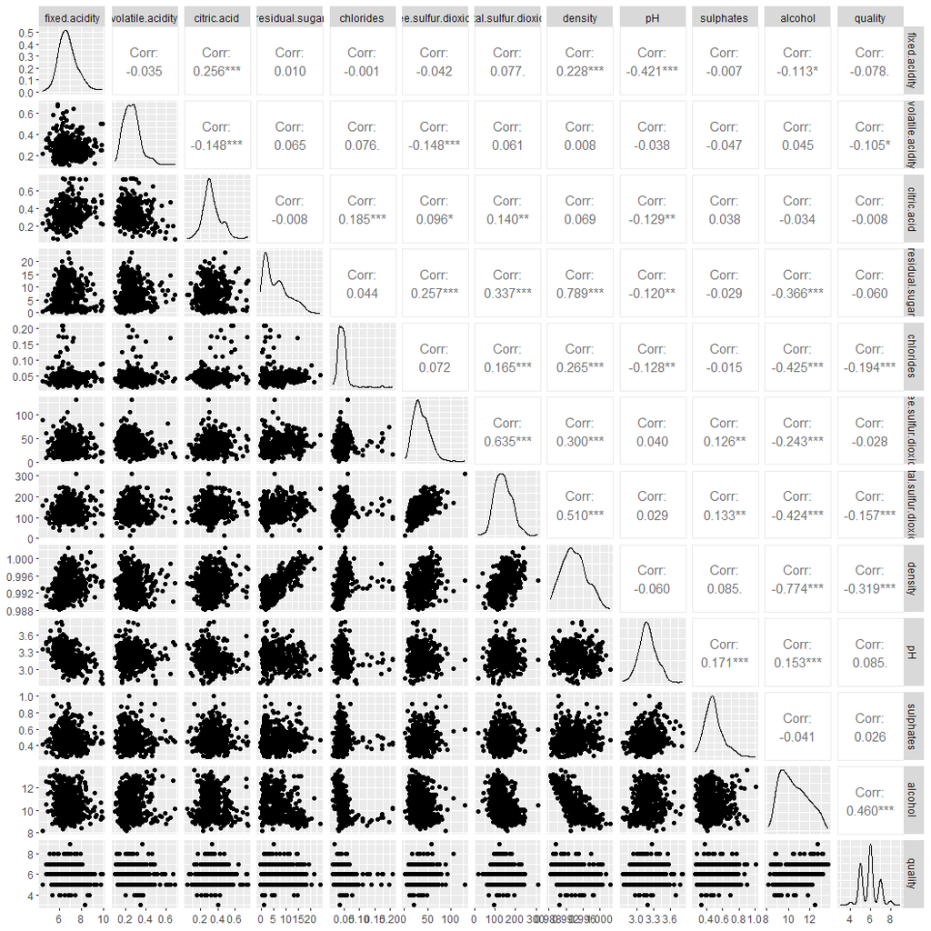

Fig A3 : Simulated Data GGpairs

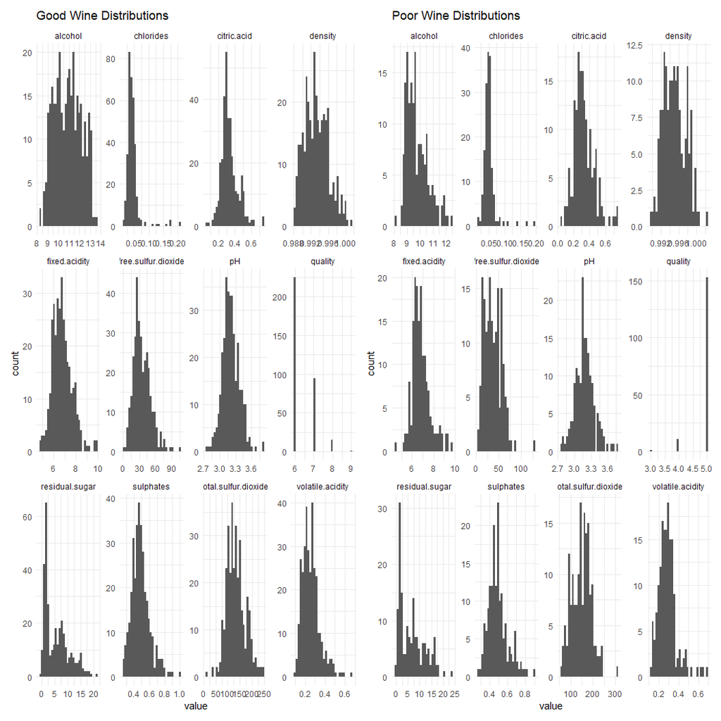

Fig A4 : Histograms of Predictors Grouped by Quality

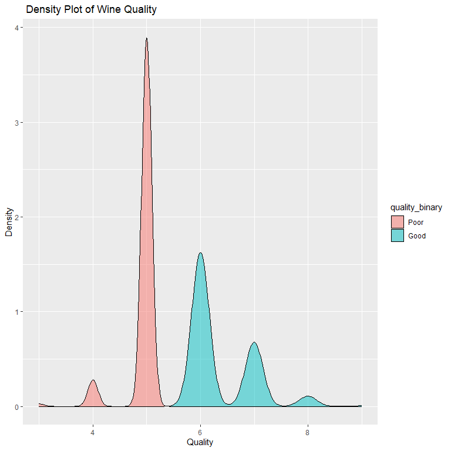